# **ML1 : Insurance - case study**

## **Classification**

*Author: Paula Gwanchele*

The project is about building a model explaining travel insurance claim outcomes based on the training sample and generate predictions for all observations from the test sample.

# **1. Load Data and Modules**

```python
import pandas as pd
import numpy as np
import matplotlib.pyplot as plt
import seaborn as sns
import warnings
warnings.filterwarnings("ignore")
from scipy.stats import chi2_contingency, f_oneway, fisher_exact
from sklearn.model_selection import train_test_split, cross_val_score, GridSearchCV
from sklearn.preprocessing import StandardScaler
from sklearn.metrics import balanced_accuracy_score, classification_report, confusion_matrix
from sklearn.feature_selection import RFE
from scipy.stats import pearsonr, spearmanr, kendalltau

# ML Models
from sklearn.linear_model import LogisticRegression, RidgeClassifier, Lasso
from sklearn.neighbors import KNeighborsClassifier
from sklearn.svm import SVC

# Optional: ensemble models
from xgboost import XGBClassifier
from lightgbm import LGBMClassifier
from sklearn.ensemble import VotingClassifier
from mlxtend.classifier import StackingClassifier
sns.set(style='white', context='notebook', palette='deep')
```

```python
# Load data
train_df = pd.read_csv('insurance_train.csv')
test_df = pd.read_csv('insurance_test.csv')
```

# **2. Exploratory Data Analysis**

Initial exploration: **Dataset description**

The dataset includes travel insurance policy records with the following 14 columns:

- *`reward`* – Commission value earned on the insurance sale
- *`claim_status`* – Target variable (0 = Not Approved, 1 = Approved) Only in training sample
- *`person_gender`* – Gender identifier of the insured person
- *`entity_type`* – Type of selling entity
- *`channel`* – Distribution channel used
- *`support_interactions`* – Number of customer service interactions
- *`agent_id`* – Identifier for the selling agent
- *`customer_score`* – Computed value between 0-1 based on customer metrics
- *`entity_a`* – Identifier of the agency that sold the policy
- *`person_age`* – Age of the insured person
- *`location`* – Destination of the trip
- *`revenue`* – Net sales value of the policy (when <0 it covers discounts)
- *`product_id`* – Name of the insurance product
- *`trip_length`* – Duration of the insured trip in days

## **A broad overview:** The types of data, shape and content

```python
train_df.head()
```

|  | reward | claim_status | person_gender | entity_type | channel | support_interactions | agent_id | customer_score | entity_a | person_age | location | revenue | product_id | trip_length |
| --- | --- | --- | --- | --- | --- | --- | --- | --- | --- | --- | --- | --- | --- | --- |
| 0 | 0.000000 | 0 | 9b2d5b46 | type_a | web | 0 | agt_0004 | 0.284509 | 50b3e71e | 51 | united states | 105.459587 | SecurePlan Flex | 21 |
| 1 | 18.428627 | 0 | 9b2d5b46 | type_a | web | 0 | agt_0001 | 0.207538 | 96d6c6df | 32 | spain | 30.433459 | DriveSafe Rental Addon | 6 |
| 2 | 0.000000 | 0 | 9b2d5b46 | type_a | web | 1 | agt_0004 | 0.300461 | 50b3e71e | 38 | new zealand | 78.728474 | TripGuard Cancel | 84 |
| 3 | 0.000000 | 0 | 9b2d5b46 | type_a | web | 0 | agt_0004 | 0.132404 | 50b3e71e | 30 | thailand | 17.146843 | TripGuard Cancel | 39 |
| 4 | 0.000000 | 0 | 9b2d5b46 | type_a | web | 2 | agt_0004 | 0.070443 | 50b3e71e | 37 | viet nam | 10.476416 | TripGuard Cancel | 48 |

```python
train_df.tail()
```

|  | reward | claim_status | person_gender | entity_type | channel | support_interactions | agent_id | customer_score | entity_a | person_age | location | revenue | product_id | trip_length |
| --- | --- | --- | --- | --- | --- | --- | --- | --- | --- | --- | --- | --- | --- | --- |
| 56988 | 0.000000 | 0 | 9b2d5b46 | type_a | web | 2 | agt_0004 | 0.215861 | 50b3e71e | 37 | singapore | 48.761445 | TripGuard Cancel | 75 |
| 56989 | 0.000000 | 0 | 9b2d5b46 | type_a | web | 1 | agt_0004 | 0.146073 | 50b3e71e | 36 | malaysia | 13.318716 | TripGuard Cancel | 2 |
| 56990 | 0.000000 | 0 | 9b2d5b46 | type_a | web | 0 | agt_0004 | 0.125909 | 50b3e71e | 37 | thailand | 19.696483 | SecurePlan Flex | 17 |
| 56991 | 0.000000 | 0 | 9b2d5b46 | type_a | web | 0 | agt_0004 | 0.153940 | 50b3e71e | 37 | south africa | 9.611168 | TripGuard Cancel | 13 |
| 56992 | 1.129819 | 0 | 9b2d5b46 | type_b | web | 0 | agt_0008 | 0.228854 | b5e4bb23 | 50 | singapore | 4.247767 | TripGuard TicketCover | 107 |

```python
test_df.head()
```

|  | reward | person_gender | entity_type | channel | support_interactions | agent_id | customer_score | entity_a | person_age | location | revenue | product_id | trip_length |
| --- | --- | --- | --- | --- | --- | --- | --- | --- | --- | --- | --- | --- | --- |
| 0 | 84.316320 | 9b2d5b46 | type_a | web | 2 | agt_0001 | 0.009257 | 96d6c6df | 31 | ireland | -141.716239 | DriveSafe Rental Addon | 73 |
| 1 | 45.884363 | 9b2d5b46 | type_a | web | 0 | agt_0001 | 0.108049 | 96d6c6df | 29 | australia | 82.225268 | DriveSafe Rental Addon | 25 |
| 2 | 0.000000 | 9b2d5b46 | type_a | web | 2 | agt_0004 | 0.108814 | 50b3e71e | 26 | indonesia | 10.247118 | TripGuard Cancel | 6 |
| 3 | 29.363482 | f67ab10a | type_b | web | 1 | agt_0002 | 0.215505 | 7b5dbb09 | 32 | france | 83.483247 | TravelShield Value | 73 |
| 4 | 12.440951 | 08f27188 | type_b | web | 0 | agt_0005 | 0.194798 | 99ede4e4 | 26 | singapore | 46.679372 | TravelShield Plus | 32 |

```python
train_df.info()
```

```
<class 'pandas.core.frame.DataFrame'>
RangeIndex: 56993 entries, 0 to 56992
Data columns (total 14 columns):
 #   Column                Non-Null Count  Dtype
---  ------                --------------  -----
 0   reward                56993 non-null  float64
 1   claim_status          56993 non-null  int64
 2   person_gender         56993 non-null  object
 3   entity_type           56993 non-null  object
 4   channel               56993 non-null  object
 5   support_interactions  56993 non-null  int64
 6   agent_id              56993 non-null  object
 7   customer_score        56993 non-null  float64
 8   entity_a              56993 non-null  object
 9   person_age            56993 non-null  int64
 10  location              56993 non-null  object
 11  revenue               56993 non-null  float64
 12  product_id            56993 non-null  object
 13  trip_length           56993 non-null  int64
dtypes: float64(3), int64(4), object(7)
memory usage: 6.1+ MB
```

```python
# Unique values in person_gender
print("Unique values in person_gender:")
print(train_df['person_gender'].value_counts())
```

```
Unique values in person_gender:
person_gender
9b2d5b46    40643
08f27188     8379
f67ab10a     7971
Name: count, dtype: int64
```

```python
train_df.describe()
```

|  | reward | claim_status | support_interactions | customer_score | person_age | revenue | trip_length |
| --- | --- | --- | --- | --- | --- | --- | --- |
| count | 56993.000000 | 56993.000000 | 56993.000000 | 56993.000000 | 56993.000000 | 56993.000000 | 56993.000000 |
| mean | 9.794976 | 0.014633 | 1.093941 | 0.189540 | 39.697261 | 40.750070 | 49.234888 |
| std | 19.791119 | 0.120081 | 0.923113 | 0.080641 | 12.603433 | 48.749221 | 98.659469 |
| min | 0.000000 | 0.000000 | 0.000000 | 0.000000 | 18.000000 | -406.642669 | 1.000000 |
| 25% | 0.000000 | 0.000000 | 0.000000 | 0.136389 | 34.000000 | 18.246389 | 9.000000 |
| 50% | 0.000000 | 0.000000 | 1.000000 | 0.181041 | 36.000000 | 26.785242 | 22.000000 |
| 75% | 11.336612 | 0.000000 | 2.000000 | 0.230836 | 44.000000 | 47.809948 | 53.000000 |
| max | 282.073580 | 1.000000 | 6.000000 | 1.000000 | 100.000000 | 801.049866 | 4856.000000 |

### 🔍 Column-by-Column Insights:

- **`reward`**:
  - Represents the commission earned on the sale.
  - Mean = 9.79, but 25%, 50% percentiles are all **0**, suggesting **many zero values**.
  - Max = 282.07, indicating a **long right tail** (heavily skewed).
  - **Action**: **log transformation** or **normalization** to handle skewness.
- **`claim_status`** (Target Variable):
  - Mean = 0.0146 → only **~1.5% of claims are approved**.
  - Indicates **extreme class imbalance**.
  - This leads to the use of **balanced accuracy** and consideration of **class weighting** or **resampling techniques** during modeling.
- **`support_interactions`**:
  - Ranges from 0 to 6; Mean ≈ 1.09.
  - May be useful if more support = higher claim approval.
  - **Action**: To include in modeling, possibly there is a need to scale for some algorithms (e.g., KNN, SVM).
- **`customer_score`**:
  - Ranges from 0 to 1, Mean ≈ 0.19.
  - Appears reasonably distributed but slightly right-skewed.
- **`person_age`**:
  - Range: 18 to 100 years; Mean ≈ 39.7.
  - Most ages lie between 34–44 (25th to 75th percentile).
  - **Action**: Could bin into age groups (e.g., young, adult, senior) or keep continuous.
- **`revenue`**:
  - Huge range: **-406.6** to **801.0**.
  - Negative values represent **discounts**.
  - Highly skewed and might affect models.
  - **Action**: to apply **log or capped transformation**.
- **`trip_length`**:
  - Most trips are between **9 to 53 days**, but max is **4856 days** (~13 years!).
  - Likely contains **data entry errors or outliers**.
  - **Action**: To Cap extreme values or treat as outliers.

### *Shape*

```python
print(f'Loaded data with shape: {train_df.shape}')
```

```
Loaded data with shape: (56993, 14)
```

### *Missing values*

```python
train_df.isna().sum()
```

```
reward                  0
claim_status            0
person_gender           0
entity_type             0
channel                 0
support_interactions    0
agent_id                0
customer_score          0
entity_a                0
person_age              0
location                0
revenue                 0
product_id              0
trip_length             0
dtype: int64
```

### *Visualization*

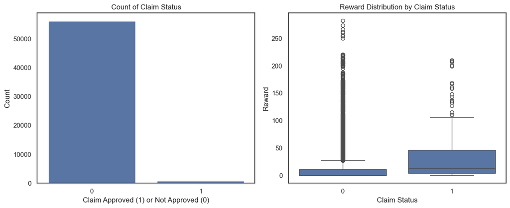

```python
#Target variable distribution
# Create a figure with 2 subplots side by side
plt.figure(figsize=(12, 5))
# Subplot 1: Countplot of claim_status
plt.subplot(1, 2, 1)
sns.countplot(x='claim_status', data=train_df)
plt.title('Count of Claim Status')
plt.xlabel('Claim Approved (1) or Not Approved (0)')
plt.ylabel('Count')

# Subplot 2: Boxplot of reward by claim_status
plt.subplot(1, 2, 2)
sns.boxplot(x='claim_status', y='reward', data=train_df)
plt.title('Reward Distribution by Claim Status')
plt.xlabel('Claim Status')
plt.ylabel('Reward')

# Show both plots
plt.tight_layout()
plt.show()
```

### Interpretation;

*from the countplot:* The dataset is heavily imbalanced, with less than 2% approved claims. This makes balanced accuracy a more appropriate evaluation metric.  
*from the boxplot:* Approved claims tend to have higher rewards, while non-approved ones often have zero. This suggests reward could be a useful predictor, but due to its skewed distribution, we engineered a binary feature `reward_given` to better capture this signal.

### Overlapping histograms let you see separation between classes(approved/not approved) for numeric features.

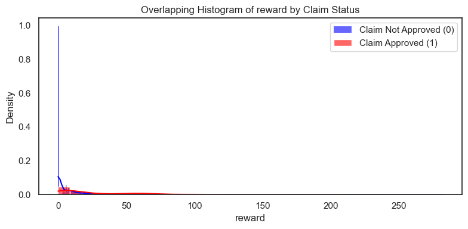

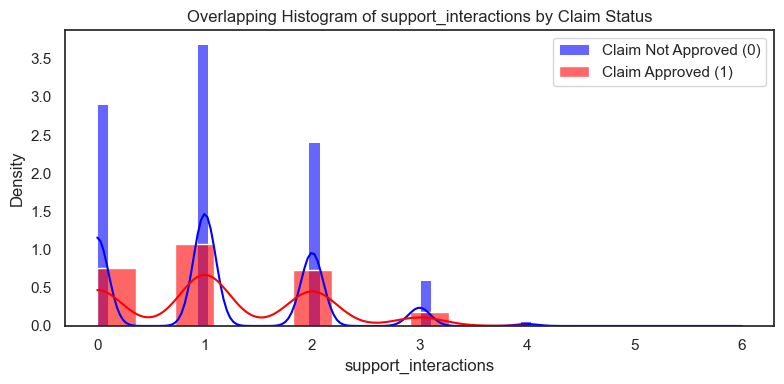

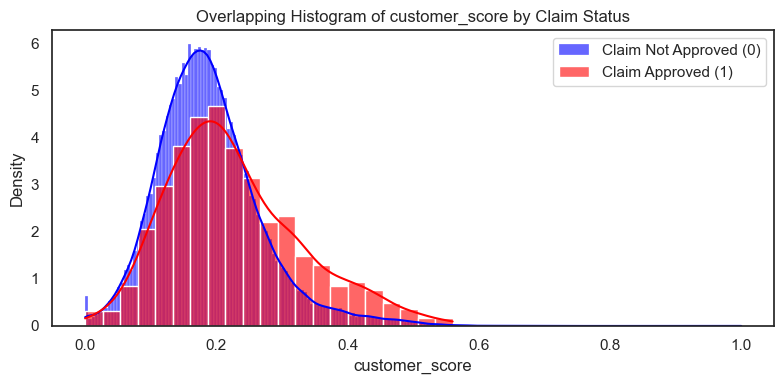

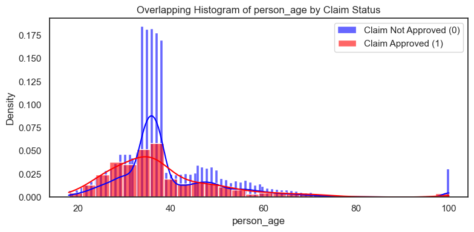

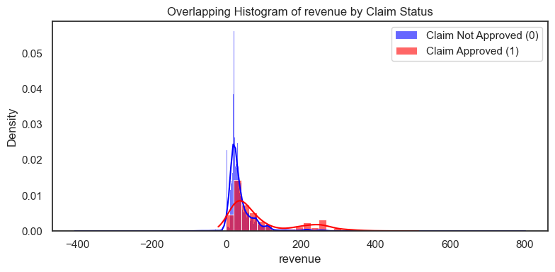

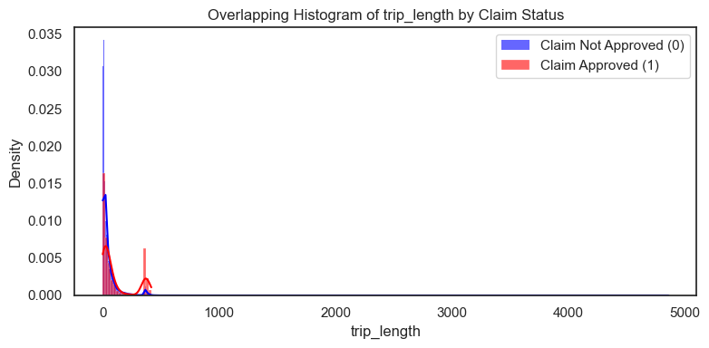

```python
# Plot overlapping histograms for numerical (ordinal) features
numerical_features = ['reward', 'support_interactions', 'customer_score', 'person_age', 'revenue', 'trip_length']

for feature in numerical_features:
    plt.figure(figsize=(8, 4))
    sns.histplot(train_df[train_df['claim_status'] == 0][feature], label='Claim Not Approved (0)', kde=True, color='blue', stat='density', alpha=0.6)
    sns.histplot(train_df[train_df['claim_status'] == 1][feature], label='Claim Approved (1)', kde=True, color='red', stat='density', alpha=0.6)
    plt.title(f"Overlapping Histogram of {feature} by Claim Status")
    plt.legend()
    plt.xlabel(feature)
    plt.ylabel("Density")
    plt.tight_layout()
    plt.show()
```

### Bar Plots Showing Mean Claim Approval Rate by Categorical Feature

- This code visualizes how likely a travel insurance claim is to be approved depending on the value of a categorical feature (e.g., gender, channel, location).
- This gives insight into which groups tend to have higher or lower approval rates, helping identify potentially influential features.

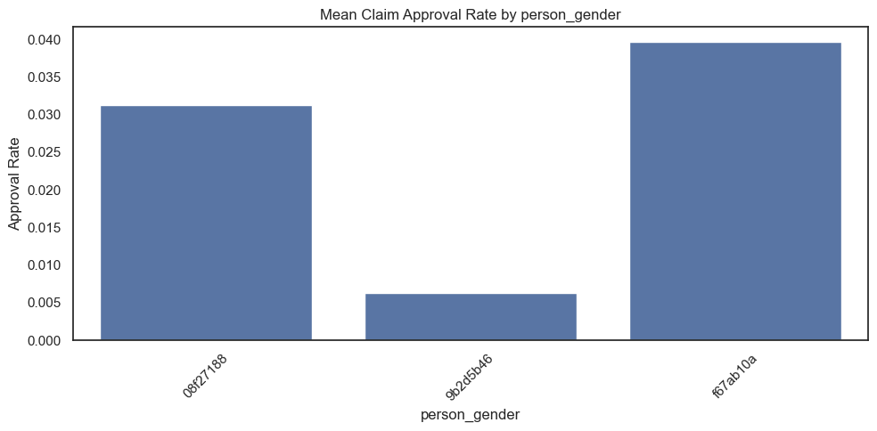

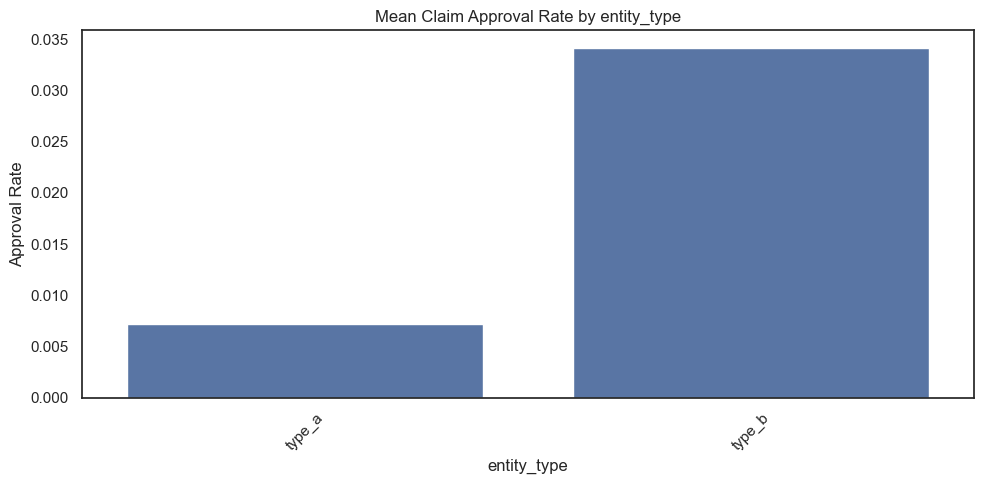

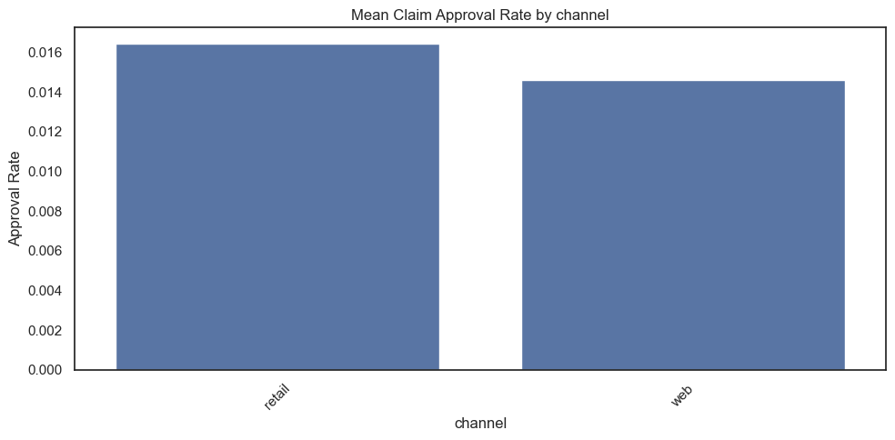

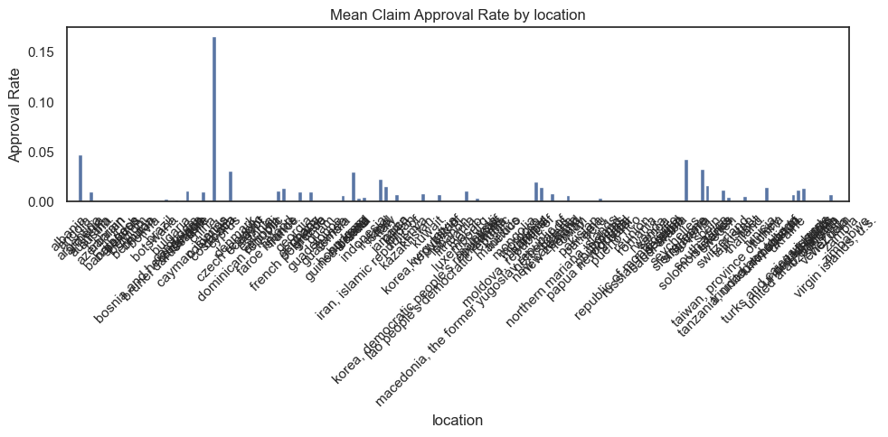

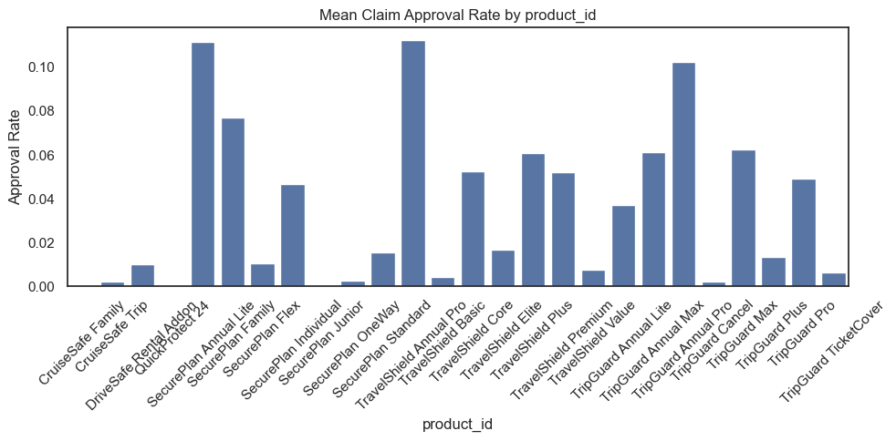

```python
categorical_features = ['person_gender', 'entity_type', 'channel', 'location', 'product_id']

for feature in categorical_features:
    plt.figure(figsize=(10, 5))
    mean_vals = train_df.groupby(feature)['claim_status'].mean()
    sns.barplot(x=mean_vals.index, y=mean_vals.values)
    plt.title(f"Mean Claim Approval Rate by {feature}")
    plt.ylabel("Approval Rate")
    plt.xlabel(feature)
    plt.xticks(rotation=45)
    plt.tight_layout()
    plt.show()
```

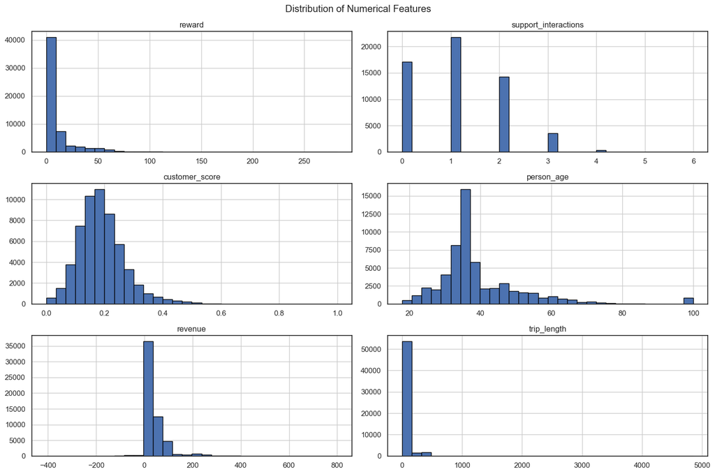

```python
# Histograms for numerical features
num_cols = ['reward', 'support_interactions', 'customer_score', 'person_age', 'revenue', 'trip_length']
train_df[num_cols].hist(bins=30, figsize=(15, 10), layout=(3, 2), edgecolor='black')
plt.suptitle('Distribution of Numerical Features')
plt.tight_layout()
plt.show()
```

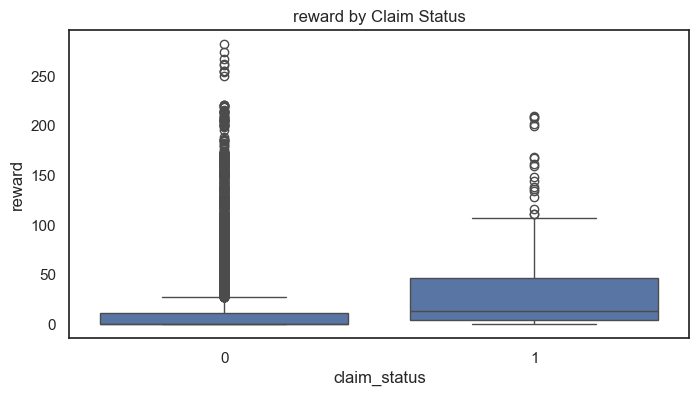

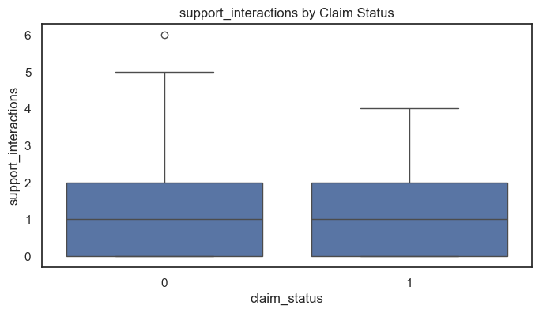

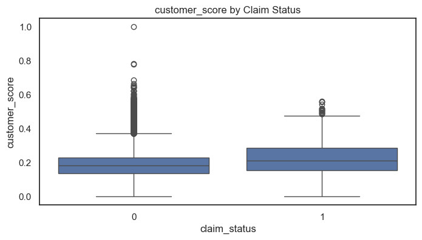

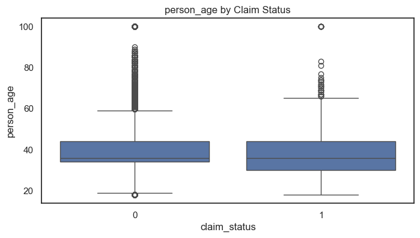

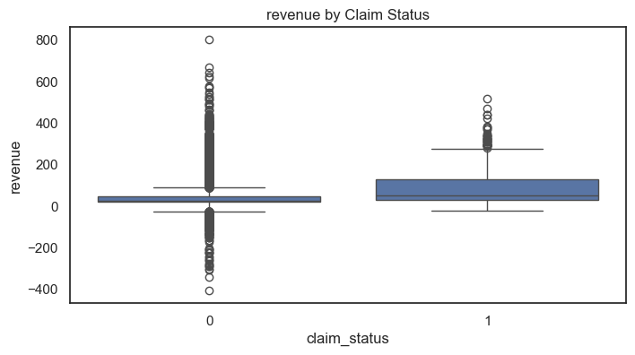

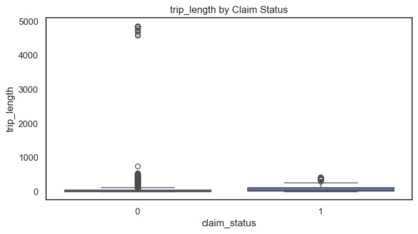

```python
# Boxplots by claim status
for col in num_cols:
    plt.figure(figsize=(8, 4))
    sns.boxplot(x='claim_status', y=col, data=train_df)
    plt.title(f'{col} by Claim Status')
    plt.show()
```

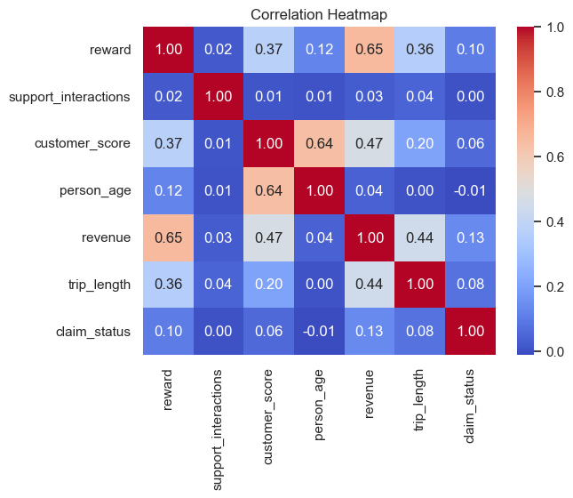

```python
# Correlation heatmap
corr = train_df[num_cols + ['claim_status']].corr()
sns.heatmap(corr, annot=True, cmap='coolwarm', fmt=".2f")
plt.title('Correlation Heatmap')
plt.show()
```

```python
# Chi-Square Test for Categorical Features to assess corr with the target variable
from scipy.stats import chi2_contingency

print("Chi-Square Test Results for Categorical Features vs claim_status:\n")

categorical_features = ['person_gender', 'entity_type', 'channel', 'location', 'product_id']

for feature in categorical_features:
    contingency_table = pd.crosstab(train_df[feature], train_df['claim_status'])
    chi2, p, dof, ex = chi2_contingency(contingency_table)
    print(f"{feature}: chi2 = {chi2:.2f}, p-value = {p:.4f}")
    if p < 0.05:
        print("  → Significant relationship with claim_status\n")
    else:
        print("  → No significant relationship with claim_status\n")
```

```
Chi-Square Test Results for Categorical Features vs claim_status:

person_gender: chi2 = 702.40, p-value = 0.0000
  → Significant relationship with claim_status

entity_type: chi2 = 570.28, p-value = 0.0000
  → Significant relationship with claim_status

channel: chi2 = 0.11, p-value = 0.7371
  → No significant relationship with claim_status

location: chi2 = 875.21, p-value = 0.0000
  → Significant relationship with claim_status

product_id: chi2 = 2021.02, p-value = 0.0000
  → Significant relationship with claim_status
```

```python
# Pearson, Spearman, Kendall correlation with target
print("\nCorrelation of numerical features with claim_status:\n")
pearson_list, spearman_list, kendall_list = [], [], []

for col in num_cols:
    pearson, _ = pearsonr(train_df[col], train_df['claim_status'])
    spearman, _ = spearmanr(train_df[col], train_df['claim_status'])
    kendall, _ = kendalltau(train_df[col], train_df['claim_status'])
    pearson_list.append(pearson)
    spearman_list.append(spearman)
    kendall_list.append(kendall)
    print(f"{col}:")
    print(f"  Pearson: {pearson:.4f}")
    print(f"  Spearman: {spearman:.4f}")
    print(f"  Kendall:  {kendall:.4f}\n")
```

```
Correlation of numerical features with claim_status:

reward:
  Pearson: 0.0996
  Spearman: 0.0959
  Kendall:  0.0857

support_interactions:
  Pearson: 0.0042
  Spearman: 0.0055
  Kendall:  0.0051

customer_score:
  Pearson: 0.0563
  Spearman: 0.0443
  Kendall:  0.0362

person_age:
  Pearson: -0.0115
  Spearman: -0.0202
  Kendall:  -0.0169

revenue:
  Pearson: 0.1348
  Spearman: 0.0902
  Kendall:  0.0737

trip_length:
  Pearson: 0.0777
  Spearman: 0.0554
  Kendall:  0.0456
```

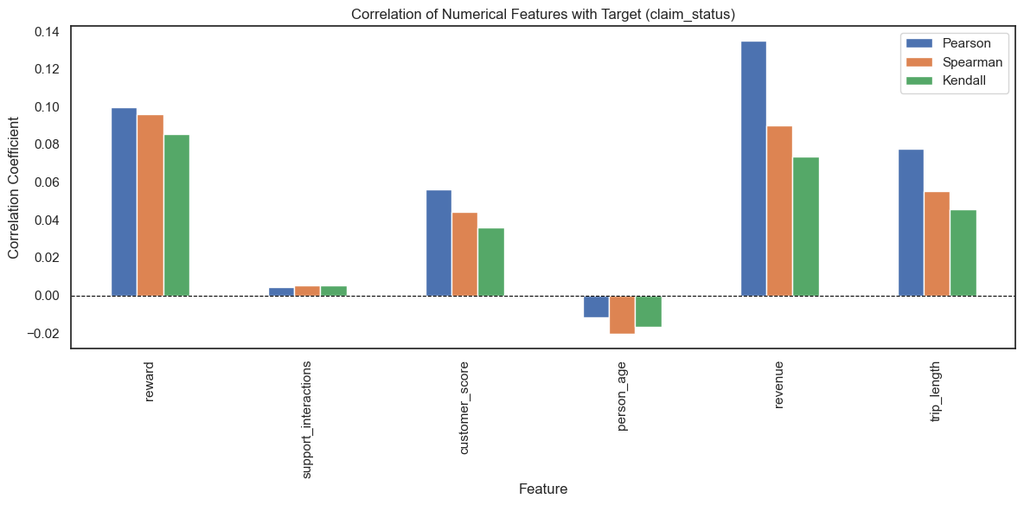

```python
# Visualize correlations
cor_df = pd.DataFrame({
    'Feature': num_cols,
    'Pearson': pearson_list,
    'Spearman': spearman_list,
    'Kendall': kendall_list
})
cor_df.set_index('Feature').plot(kind='bar', figsize=(12, 6))
plt.title('Correlation of Numerical Features with Target (claim_status)')
plt.ylabel('Correlation Coefficient')
plt.axhline(0, color='black', linewidth=0.8, linestyle='--')
plt.tight_layout()
plt.show()
```

### Key Takeaways

- Among all numeric features, `revenue` is the most promising predictor of claim approval.
- Other features like `reward` and `trip_length` may offer weak but helpful signals.
- `support_interactions` and `person_age` are likely not helpful for prediction and could be dropped or de-prioritized.
- `customer_score` shows a slight positive trend — better scoring customers are a little more likely to be approved.
- Pearson, Spearman, and Kendall results agree closely, giving confidence in these conclusions.

# **3. Feature Engineering**

*3.1 Handle Skewness & Outliers*

```python
# Cap trip_length at 99th percentile
trip_cap = train_df['trip_length'].quantile(0.99)
train_df['trip_length'] = np.where(train_df['trip_length'] > trip_cap, trip_cap, train_df['trip_length'])

# Log transform revenue (offset to avoid negative/0)
train_df['log_revenue'] = np.log1p(train_df['revenue'] - train_df['revenue'].min() + 1)

# Binary feature: was a reward given this helps with removing the 50% of the zeros
train_df['reward_given'] = (train_df['reward'] > 0).astype(int)

# I need to fix for test_df as well
trip_cap = train_df['trip_length'].quantile(0.99)
test_df['trip_length'] = np.where(test_df['trip_length'] > trip_cap, trip_cap, test_df['trip_length'])

# Create binary reward feature
test_df['reward_given'] = (test_df['reward'] > 0).astype(int)

# Log transform revenue using same offset
revenue_offset = train_df['revenue'].min()
test_df['log_revenue'] = np.log1p(test_df['revenue'] - revenue_offset + 1)
```

*3.2 Encode Categorical Variables*

```python
train_df = pd.get_dummies(train_df, columns=['person_gender', 'entity_type', 'channel', 'location', 'product_id'], drop_first=True)
```

```python
categorical_cols = ['person_gender', 'entity_type', 'channel', 'location', 'product_id']
# One-hot encode
test_df = pd.get_dummies(test_df, columns=categorical_cols, drop_first=True)
```

*3.3 Drop High Cardinality Columns* : columns with less impact  
For `reward` and `revenue` only their old versions will be dropped as they might affect the models

```python
train_df.drop(['agent_id', 'entity_a', 'reward', 'revenue'], axis=1, inplace=True)

# Drop original versions
test_df.drop(['reward', 'revenue', 'agent_id', 'entity_a'], axis=1, inplace=True)
```

```python
X = train_df.drop('claim_status', axis=1)
y = train_df['claim_status']

#Align test_df to have same columns as X_train (fill missing columns with 0s)
test_df = test_df.reindex(columns=X.columns, fill_value=0)
```

*3.4 Split Features & Target*

- when preparing data for modeling, I need to separate target (what I want to predict) and its features (inputs).

### Data Splitting

Use internal split to properly assess model performance. *1st split;*  
X_train = 60%  
X_temp (which becomes validation + test) = 40%

*2nd split;*  
X_val = 20%  
X_test = 20%

```python
X_train, X_temp, y_train, y_temp = train_test_split(X, y, test_size=0.4, stratify=y, random_state=42)
X_val, X_test, y_val, y_test = train_test_split(X_temp, y_temp, test_size=0.5, stratify=y_temp, random_state=42)
```

### Feature Scaling

*Apply only to algorithms sensitive to magnitude (KNN, SVM).*

```python
scaler = StandardScaler()
X_train_scaled = scaler.fit_transform(X_train)
X_val_scaled = scaler.transform(X_val)
X_test_scaled = scaler.transform(X_test)
test_scaled = scaler.transform(test_df)
```

# **4. Modeling & Cross-Validation**

### *4.1 Logistic Regression (baseline)*

```python
log_model = LogisticRegression(class_weight='balanced', max_iter=1000)
log_model.fit(X_train_scaled, y_train)
```

```
LogisticRegression(class_weight='balanced', max_iter=1000)
```

### *4.2 K-Nearest Neighbors*

```python
knn = KNeighborsClassifier(n_neighbors=5)
knn.fit(X_train_scaled, y_train)
```

```
KNeighborsClassifier()
```

### *4.3 Support Vector Machine*

```python
svm_model = SVC(kernel='rbf', class_weight='balanced', probability=True)
svm_model.fit(X_train_scaled, y_train)
```

```
SVC(class_weight='balanced', probability=True)
```

# **5. Model Evaluation**

Use balanced accuracy for all comparisons.

```python
from sklearn.metrics import balanced_accuracy_score

models = {'Logistic Regression': log_model, 'KNN': knn, 'SVM': svm_model}
for name, model in models.items():
    y_pred = model.predict(X_test_scaled)
    score = balanced_accuracy_score(y_test, y_pred)
    print(f'{name}: Balanced Accuracy = {score:.4f}')
```

```
Logistic Regression: Balanced Accuracy = 0.7305
KNN: Balanced Accuracy = 0.4998
SVM: Balanced Accuracy = 0.7450
```

### 🧠 Interpretation:

- Balanced Accuracy = average of recall for each class (approved vs not approved). My dataset is imbalanced, so accuracy alone would be misleading.
- I compared Logistic Regression, KNN, and SVM using balanced accuracy. SVM performed the best with a score of 0.7450, followed closely by Logistic Regression at 0.7305. KNN performed poorly (0.4998), likely due to the high dimensionality and class imbalance. We selected SVM as my final model for predictions on this 1st round.”

### Extra step; Feature Selection

Choosing the most important or predictive features (e.g., RFE, XGBoost, feature importance)

### Logistic Regression Feature Importance

This shows which features increase or decrease the probability of a claim being approved.

```python
log_importance = pd.DataFrame({'Feature': X.columns, 'Coefficient': log_model.coef_[0]})
log_importance['Abs'] = log_importance['Coefficient'].abs()
log_importance.sort_values(by='Abs', ascending=False, inplace=True)
print("Top features (Logistic Regression):")
print(log_importance[['Feature', 'Coefficient']].head(10))
```

```
Top features (Logistic Regression):
                           Feature  Coefficient
6           person_gender_9b2d5b46    -1.448455
94                location_myanmar    -0.688262
8               entity_type_type_b    -0.587823
29               location_cambodia    -0.545946
157     product_id_QuickProtect 24    -0.487502
166  product_id_TravelShield Basic    -0.481547
167   product_id_TravelShield Core     0.476217
155     product_id_CruiseSafe Trip    -0.448847
4                      log_revenue     0.431674
129             location_sri lanka    -0.426489
```

-> I looked at how strongly each feature affects the output (positive or negative).

Features with larger absolute coefficients (e.g., gender, location_myanmar) are more influential.

### XGBoost Feature Importance

More robust for non-linear relationships.

```python
xgb_model = XGBClassifier(use_label_encoder=False, eval_metric='logloss')
xgb_model.fit(X_train_scaled, y_train)
xgb_importance = pd.DataFrame({
    'Feature': X.columns,
    'Importance': xgb_model.feature_importances_
}).sort_values(by='Importance', ascending=False)
print("Top features (XGBoost):")
print(xgb_importance.head(10))
```

```
Top features (XGBoost):
                               Feature  Importance
6               person_gender_9b2d5b46    0.137886
124                 location_singapore    0.134241
175        product_id_TripGuard Cancel    0.056565
167       product_id_TravelShield Core    0.055923
169       product_id_TravelShield Plus    0.046576
8                   entity_type_type_b    0.020018
174    product_id_TripGuard Annual Pro    0.019899
158  product_id_SecurePlan Annual Lite    0.019827
34                      location_china    0.019426
4                          log_revenue    0.018244
```

-> `XGBoost` ranks features by how often and how effectively they split data in decision trees.

Top feature: again `person_gender`_9b2d5b46, followed by `location`_singapore.

### Recursive Feature Elimination (RFE)

I used this to identify the most impactful features.  
RFE is a wrapper method that recursively removes the least important features and keeps the top ones.

```python
rfe = RFE(log_model, n_features_to_select=10)
rfe.fit(X_train_scaled, y_train)
selected_features = X.columns[rfe.support_]
print("Top 10 features by RFE:")
print(selected_features)
```

```
Top 10 features by RFE:
Index(['person_gender_9b2d5b46', 'location_cambodia', 'location_ireland',
       'location_myanmar', 'location_norway', 'location_sri lanka',
       'product_id_DriveSafe Rental Addon', 'product_id_QuickProtect 24',
       'product_id_SecurePlan Flex', 'product_id_TravelShield Basic'],
      dtype='object')
```

### Reduce feature set

```python
# Use only the selected features
selected_features = ['person_gender_9b2d5b46', 'location_cambodia', 'location_ireland',
                     'location_myanmar', 'location_norway', 'location_sri lanka',
                     'product_id_DriveSafe Rental Addon', 'product_id_QuickProtect 24',
                     'product_id_SecurePlan Flex', 'product_id_TravelShield Basic']

# Slice train and test sets
X_train_sel = X_train[selected_features]
X_val_sel = X_val[selected_features]
X_test_sel = X_test[selected_features]

# Scale only the selected features
scaler_sel = StandardScaler()
X_train_sel_scaled = scaler_sel.fit_transform(X_train_sel)
X_val_sel_scaled = scaler_sel.transform(X_val_sel)
X_test_sel_scaled = scaler_sel.transform(X_test_sel)
```

### Retrain Models using only selected features

```python
# Refit models using only selected features
log_model_sel = LogisticRegression(class_weight='balanced', max_iter=1000)
log_model_sel.fit(X_train_sel_scaled, y_train)

knn_sel = KNeighborsClassifier(n_neighbors=5)
knn_sel.fit(X_train_sel_scaled, y_train)

svm_model_sel = SVC(kernel='rbf', class_weight='balanced', probability=True)
svm_model_sel.fit(X_train_sel_scaled, y_train)
```

```
SVC(class_weight='balanced', probability=True)
```

### Re-evaluate model performance

```python
models_sel = {'Logistic Regression': log_model_sel, 'KNN': knn_sel, 'SVM': svm_model_sel}

for name, model in models_sel.items():
    y_pred = model.predict(X_test_sel_scaled)
    score = balanced_accuracy_score(y_test, y_pred)
    print(f'{name} (Selected Features): Balanced Accuracy = {score:.4f}')
```

```
Logistic Regression (Selected Features): Balanced Accuracy = 0.7386
KNN (Selected Features): Balanced Accuracy = 0.5000
SVM (Selected Features): Balanced Accuracy = 0.7387
```

# Final Model & Test Predictions

The model that will be presented in the final report

```python
# ✅ STEP 10: Predict on Test Set and Export
final_predictions = svm_model.predict(test_scaled)
```

```python
#Save to CSV
submission = pd.DataFrame({
    'id': test_df.index,
    'claim_status': final_predictions
})
submission.to_csv('final_predictions.csv', index=False)
print("✅Final predictions saved to final_predictions.csv")
```

```
✅Final predictions saved to final_predictions.csv
```